# Distributions and Simulation

**Time Estimates:**  
Videos: 30-60 min  
Readings: 10 min  
Activities: 45 min  
Check-ins: 3

## Review: Statistical Distributions

**Required Video: [Review of Statistical Distributions](https://www.youtube.com/embed/KddbZr-ssZc)**

[video not shown]

**Optional Tutorial: [Interactive Random Variable Creator](https://seeing-theory.brown.edu/probability-distributions/index.html#section1)**

## Simulating in R

**Required Video: [Simulating Data in R](https://www.youtube.com/embed/LNg7kQbXvU0)**

[video not shown]

**Optional Reading: [RProg Ch 20: Simulation](https://bookdown.org/rdpeng/rprogdatascience/simulation.html)**

**Check-In 1: The r, p, q, and d functions**

Try to predict what the following outputs will be **WITHOUT** running the code in R. Drawing pictures of the relevant distributions may help.

(Yes, it is very easy to “cheat” on this question. But this is for your practice, and I recommend you give it some thought.)

```r
## a
punif(0.674)

## b

pnorm(2)
qnorm(.975)

## c

pchisq(0, df = 12)

## d

qt(10, df = 16)

## e

dbinom(2, size = 2, prob = .4)
pbinom(1, size = 2, prob = .6)
```

## Preparing for the Lab

### The Central Limit Theorem

If you do not recall the Central Limit Theorem from you previous classes - or if you would benefit from a refresher:

**Optional Video: [The CLT](https://www.youtube.com/embed/YAlJCEDH2uY)**

**Check-In 2: The CLT**

Explain the idea behind the CLT in your own words, using as little jargon/vocabulary as you can.

### Plotting distributions

Here is the code that made one of the plots from the lecture video:

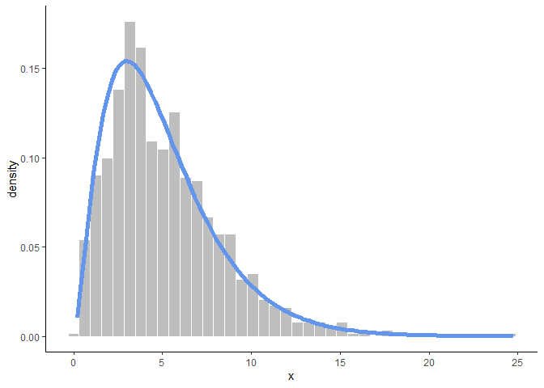

```r
my_samples <- data.frame(x = rchisq(1000, df = 5))

ggplot(my_samples, aes(x)) +
  geom_histogram(bins = 40, aes(y = ..density..), fill = "grey", col = "white") +
  stat_function(fun= ~dchisq(.x, df = 5), col = "cornflowerblue", lwd = 2) +
  theme_classic()
```

**Check-In 3: Plotting**

Re-create this plot from the lecture slides: (The two colors are “cornflowerblue” and “deeppink”)

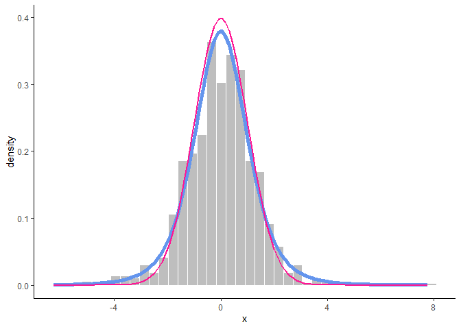